# Homework 2

Author

Kendall Dimson

##Data Wrangling

```r
#Data Wrangling
install.packages("readr")
individual_chs <- read_csv("~/Desktop/PM566/chs_individual.csv")
regional_chs <- read_csv("~/Desktop/PM566/chs_regional.csv")
head(individual_chs)
```

```
# A tibble: 6 × 23
    sid townname   male race  hispanic agepft height weight   bmi asthma
  <dbl> <chr>     <dbl> <chr>    <dbl>  <dbl>  <dbl>  <dbl> <dbl>  <dbl>
1     1 Lancaster     1 W            0  10.2     123     54  16.2      0
2     2 Lancaster     1 W            0  10.5     145     77  16.6      0
3     6 Lancaster     0 B            0  10.1     145    143  30.9      0
4     7 Lancaster     0 O            0  10.7     156     72  13.4      0
5     8 Lancaster     0 W            1   9.78    132     61  15.9      0
6    10 Lancaster     1 O            1  NA        NA     NA  NA        0
# ℹ 13 more variables: active_asthma <dbl>, father_asthma <dbl>,
#   mother_asthma <dbl>, wheeze <dbl>, hayfever <dbl>, allergy <dbl>,
#   educ_parent <dbl>, smoke <dbl>, pets <dbl>, gasstove <dbl>, fev <dbl>,
#   fvc <dbl>, mmef <dbl>
```

```r
chs <- merge (individual_chs, regional_chs, by = "townname")

head (chs)
```

```
  townname sid male race hispanic    agepft height weight      bmi asthma
1   Alpine 841    1    W        1 10.548939    150     78 15.75758      0
2   Alpine 835    0    W        0 10.099932    143     69 15.33749      0
3   Alpine 838    0    O        1  9.486653    133     62 15.93183      0
4   Alpine 840    0    W        0  9.965777    146     78 16.63283      0
5   Alpine 865    0    W        0 10.039699    162    140 24.24797      1
6   Alpine 867    0    W        1  9.957563    141     94 21.49151      0
  active_asthma father_asthma mother_asthma wheeze hayfever allergy educ_parent
1             0             0             0      0        0       0           5
2             0             0             0      0        0       1           3
3             0             0             0      0        0       0           4
4             0             0             0      0        0       0          NA
5             1             0             0      1        0       1           3
6             0            NA             0      0        0       0           5
  smoke pets gasstove      fev      fvc     mmef pm25_mass pm25_so4 pm25_no3
```

[output cut: 27 more lines]

```r
chs_rows <- nrow (chs)
nrow (individual_chs)
```

```
[1] 1200
```

```r
nrow (regional_chs)
```

```
[1] 12
```

```r
duplicates <- duplicated(chs)
n_duplicates <- sum(duplicates)

nrow(chs)
```

```
[1] 1200
```

```r
nrow(duplicates)
```

```r
#impute for missing continuousvalues
chs <- chs|>
  group_by(male, hispanic) |>
  mutate(bmi = ifelse(is.na(bmi), mean(bmi, na.rm = TRUE), bmi)) |>
  ungroup()

get_mode <- function(v) {
  uniqv <- unique(v)
  uniqv[which.max(tabulate(match(v, uniqv)))]
}

# Impute missing values for categorical variables


summary (chs)
```

```
   townname              sid              male            race
 Length:1200        Min.   :   1.0   Min.   :0.0000   Length:1200
 Class :character   1st Qu.: 528.8   1st Qu.:0.0000   Class :character
 Mode  :character   Median :1041.5   Median :0.0000   Mode  :character
                    Mean   :1037.5   Mean   :0.4917
                    3rd Qu.:1554.2   3rd Qu.:1.0000
                    Max.   :2053.0   Max.   :1.0000

    hispanic          agepft           height        weight
 Min.   :0.0000   Min.   : 8.961   Min.   :114   Min.   : 42.00
 1st Qu.:0.0000   1st Qu.: 9.610   1st Qu.:135   1st Qu.: 65.00
 Median :0.0000   Median : 9.906   Median :139   Median : 74.00
 Mean   :0.4342   Mean   : 9.924   Mean   :139   Mean   : 79.33
 3rd Qu.:1.0000   3rd Qu.:10.177   3rd Qu.:143   3rd Qu.: 89.00
 Max.   :1.0000   Max.   :12.731   Max.   :165   Max.   :207.00
                  NA's   :89       NA's   :89    NA's   :89
      bmi            asthma       active_asthma  father_asthma
 Min.   :11.30   Min.   :0.0000   Min.   :0.00   Min.   :0.00000
 1st Qu.:15.96   1st Qu.:0.0000   1st Qu.:0.00   1st Qu.:0.00000
 Median :17.81   Median :0.0000   Median :0.00   Median :0.00000
 Mean   :18.50   Mean   :0.1463   Mean   :0.19   Mean   :0.08318
 3rd Qu.:19.99   3rd Qu.:0.0000   3rd Qu.:0.00   3rd Qu.:0.00000
 Max.   :41.27   Max.   :1.0000   Max.   :1.00   Max.   :1.00000
                 NA's   :31                      NA's   :106
 mother_asthma        wheeze          hayfever         allergy
 Min.   :0.0000   Min.   :0.0000   Min.   :0.0000   Min.   :0.0000
 1st Qu.:0.0000   1st Qu.:0.0000   1st Qu.:0.0000   1st Qu.:0.0000
 Median :0.0000   Median :0.0000   Median :0.0000   Median :0.0000
 Mean   :0.1023   Mean   :0.3313   Mean   :0.1747   Mean   :0.2929
 3rd Qu.:0.0000   3rd Qu.:1.0000   3rd Qu.:0.0000   3rd Qu.:1.0000
 Max.   :1.0000   Max.   :1.0000   Max.   :1.0000   Max.   :1.0000
 NA's   :56       NA's   :71       NA's   :118      NA's   :63
  educ_parent        smoke             pets           gasstove
 Min.   :1.000   Min.   :0.0000   Min.   :0.0000   Min.   :0.0000
 1st Qu.:2.000   1st Qu.:0.0000   1st Qu.:1.0000   1st Qu.:1.0000
 Median :3.000   Median :0.0000   Median :1.0000   Median :1.0000
 Mean   :2.797   Mean   :0.1638   Mean   :0.7667   Mean   :0.7815
 3rd Qu.:3.000   3rd Qu.:0.0000   3rd Qu.:1.0000   3rd Qu.:1.0000
 Max.   :5.000   Max.   :1.0000   Max.   :1.0000   Max.   :1.0000
 NA's   :64      NA's   :40                        NA's   :33
```

[output cut: 48 more lines]

```
     iacid           oacid        total_acids          lon
 Min.   :0.760   Min.   :1.090   Min.   : 1.520   Min.   :-120.7
 1st Qu.:1.835   1st Qu.:2.978   1st Qu.: 4.930   1st Qu.:-118.8
 Median :2.825   Median :4.135   Median : 6.370   Median :-117.7
 Mean   :2.788   Mean   :4.342   Mean   : 6.708   Mean   :-118.3
 3rd Qu.:3.817   3rd Qu.:5.982   3rd Qu.: 9.395   3rd Qu.:-117.4
 Max.   :4.620   Max.   :7.400   Max.   :11.430   Max.   :-116.8

      lat
 Min.   :32.84
 1st Qu.:33.93
 Median :34.10
 Mean   :34.20
 3rd Qu.:34.65
 Max.   :35.49
```

```r
#new categorical level, obesity level
chs$obesity_level <- ifelse(chs$bmi <14, "Underweight BMI",
         ifelse(chs$bmi >=14 & chs$bmi <22, "Normal BMI",
                ifelse (chs$bmi >= 22 & chs$bmi <=24, "Overweight BMI",
                        ifelse (chs$bmi >24, "Obese BMI", NA))))

head(chs$obesity_level)
```

```
[1] "Normal BMI" "Normal BMI" "Normal BMI" "Normal BMI" "Obese BMI"
[6] "Normal BMI"
```

```r
#gasstove & smoke
chs$smoke_gas_exposure <- ifelse(chs$gasstove==1 & chs$smoke==1, "Both",
                                 ifelse (chs$gasstove==1 & chs$smoke==0, "Gas Stove Only",
                                 ifelse (chs$gasstove==0 & chs$smoke==1, "Second Hand Smoke only",
                                 ifelse(chs$gasstove==0 & chs$smoke==0, "Neither", NA))))
chs <- chs|>
  group_by(male, hispanic) |>
  mutate(
    male = ifelse(is.na(male), get_mode(male), male),
    hispanic = ifelse(is.na(hispanic), get_mode(hispanic), hispanic),
     smoke_gas_exposure = ifelse(is.na(smoke_gas_exposure), get_mode(smoke_gas_exposure), smoke_gas_exposure)
  ) |>
  ungroup()
head (chs$smoke_gas_exposure)
```

```
[1] "Neither"        "Neither"        "Gas Stove Only" "Gas Stove Only"
[5] "Gas Stove Only" "Gas Stove Only"
```

```r
#Summary by town, townname var
summarytown <- chs |> group_by(townname) |>
  summarise (
    avg_fevtown =mean(fev, na.rm=TRUE),
    sd_fevtown = sd(fev, na.rm=TRUE),
    count=n()
  )

summarytown
```

```
# A tibble: 12 × 4
   townname      avg_fevtown sd_fevtown count
   <chr>               <dbl>      <dbl> <int>
 1 Alpine              2089.       298.   100
 2 Atascadero          2079.       332.   100
 3 Lake Elsinore       2040.       318.   100
 4 Lake Gregory        2092.       338.   100
 5 Lancaster           2003.       337.   100
 6 Lompoc              2038.       367.   100
 7 Long Beach          1984.       331.   100
 8 Mira Loma           1985.       337.   100
 9 Riverside           1986.       290.   100
10 San Dimas           2028.       322.   100
11 Santa Maria         2023.       330.   100
12 Upland              2027.       357.   100
```

```r
#Summary by sex, male var
summarysex <- chs |> group_by(male) |>
  summarise (
    avg_fevsex =mean(fev, na.rm=TRUE),
    sd_fevsex = sd(fev, na.rm=TRUE),
    count=n()
  )

summarysex
```

```
# A tibble: 2 × 4
   male avg_fevsex sd_fevsex count
  <dbl>      <dbl>     <dbl> <int>
1     0      1959.      327.   610
2     1      2104.      318.   590
```

```r
#Summary by obesity level
summary_obesity_level <- chs |> group_by(obesity_level) |>
  summarise (
    avg_fevobesity_level =mean(fev, na.rm=TRUE),
    sd_fevobesity_level = sd(fev, na.rm=TRUE),
    count=n()
  )

summary_obesity_level
```

```
# A tibble: 4 × 4
  obesity_level   avg_fevobesity_level sd_fevobesity_level count
  <chr>                          <dbl>               <dbl> <int>
1 Normal BMI                     1998.                309.   975
2 Obese BMI                      2269.                326.   103
3 Overweight BMI                 2224.                317.    87
4 Underweight BMI                1687.                300.    35
```

```r
#Summary by Smoke/Gas Exposure
summary_smoke_gas <- chs |> group_by(smoke_gas_exposure) |>
  summarise (
    avg_fevsmoke_gas =mean(fev, na.rm=TRUE),
    sd_fevsmoke_gas = sd(fev, na.rm=TRUE),
    count=n()
  )

summary_smoke_gas
```

```
# A tibble: 4 × 4
  smoke_gas_exposure     avg_fevsmoke_gas sd_fevsmoke_gas count
  <chr>                             <dbl>           <dbl> <int>
1 Both                              2020.            313.   151
2 Gas Stove Only                    2024.            331.   799
3 Neither                           2060.            343.   214
4 Second Hand Smoke only            2064.            333.    36
```

##Looking at the Data (Exploratory Data Analysis)

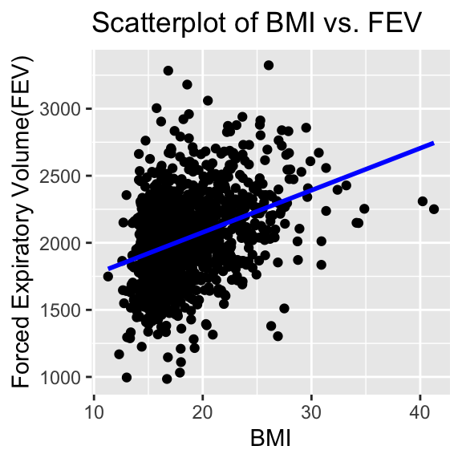

```r
#1. What is the association between BMI and FEV (forced expiratory volume)?
ggplot(chs, aes(x=bmi, y=fev))+
  geom_point()+
  labs(title = "Scatterplot of BMI vs. FEV",
       x = "BMI",
       y= "Forced Expiratory Volume(FEV)") +
  geom_smooth(method = "lm", color = "blue", se=FALSE)
```

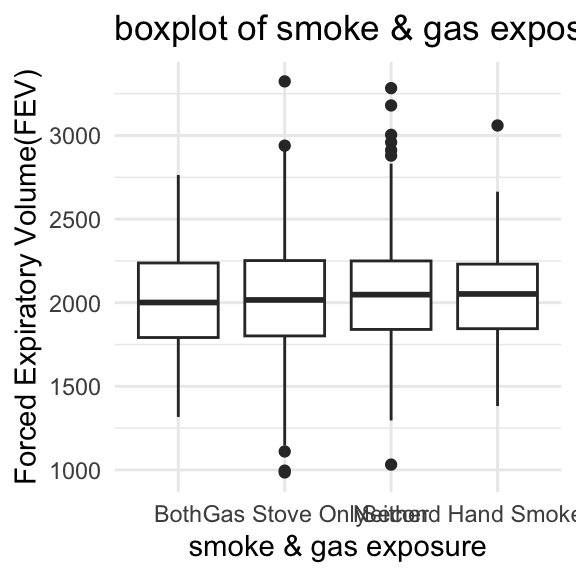

```r
#2: What is the association between smoke and gas exposure and fev?

chs <- chs |> filter (!is.na(smoke_gas_exposure))
ggplot(chs, aes(x=smoke_gas_exposure, y=fev), na.rm=TRUE)+
  geom_boxplot()+
  labs(title = "boxplot of smoke & gas exposure vs. FEV",
       x = "smoke & gas exposure",
       y= "Forced Expiratory Volume(FEV)") +
  theme_minimal()
```

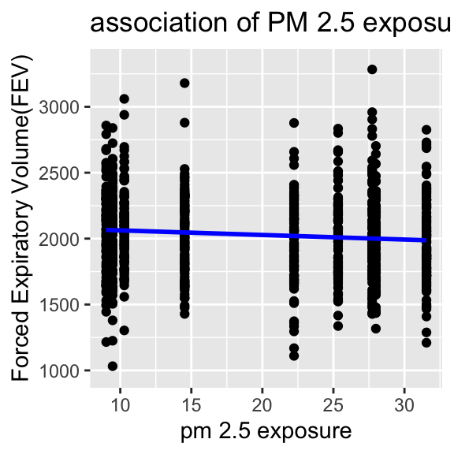

```r
#3: what is the association between PM2.5 exposure and fev?
ggplot(chs, aes(x=pm2_5_fr, y=fev), na.rm=TRUE)+
  geom_point()+
  labs(title = "association of PM 2.5 exposure vs. FEV",
       x = "pm 2.5 exposure",
       y= "Forced Expiratory Volume(FEV)") +
  geom_smooth(method = "lm", color = "blue", se=FALSE)
```

There is a positive association between BMI and FEV, such that as one’s BMI increases, it is likely that their Forced Expiratory Volume (FEV) increases as well.

Overall, there is no association between Smoke & Gas exposure and FEV. The average FEV levels is very similar regardless fo smoke&gas exposure status.

There is a slight negative association between PM 2.5 exposure and FEV. As one’s average PM2.5 exposure increases, there is a decreasse in FEV.

##Visualization

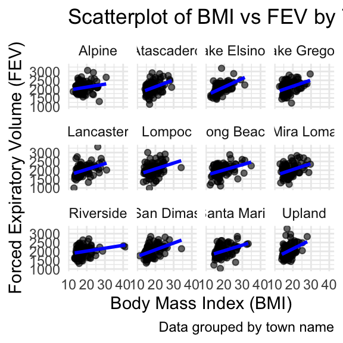

```r
#1: Facet plot showing scatterplots with regression lines of BMI vs FEV by “townname”.
ggplot(chs, aes(x = bmi, y = fev)) +
  geom_point(alpha = 0.6) +
  geom_smooth(method = "lm", se = FALSE, color = "blue") +
  facet_wrap(~ townname) +
  labs(
    title = "Scatterplot of BMI vs FEV by Town",
    x = "Body Mass Index (BMI)",
    y = "Forced Expiratory Volume (FEV)",
    caption = "Data grouped by town name"
  ) +
  theme_minimal()
```

Overall, there is a positive association between BMI and FEV as shown in each different town. As BMI increases, there is an uptick of Forced Expiratory volume in every town.

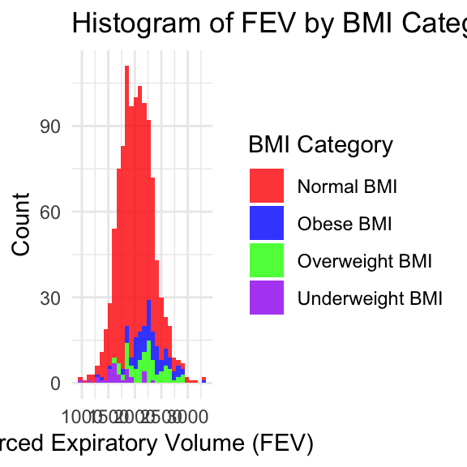

```r
#Visualization Q2 -- Stacked histograms of FEV by BMI category and FEV by smoke/gas exposure. Use different color schemes than the ggplot default.

#FEV by obesity_level
ggplot(chs, aes(x = fev, fill = obesity_level)) +
  geom_histogram(position = "stack", bins = 30, alpha = 0.8) +
  scale_fill_manual(values = c("red", "blue", "green", "purple")) +
  labs(
    title = "Histogram of FEV by BMI Category",
    x = "Forced Expiratory Volume (FEV)",
    y = "Count",
    fill = "BMI Category"
  ) +
  theme_minimal()
```

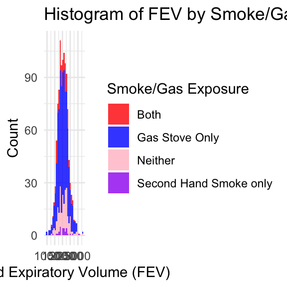

```r
#FEV by smoke/gas exposure
ggplot(chs, aes(x = fev, fill = smoke_gas_exposure)) +
  geom_histogram(position = "stack", bins = 30, alpha = 0.8) +
  scale_fill_manual(values = c("red", "blue", "pink", "purple")) +
  labs(
    title = "Histogram of FEV by Smoke/Gas Exposure",
    x = "Forced Expiratory Volume (FEV)",
    y = "Count",
    fill = "Smoke/Gas Exposure"
  ) +
  theme_minimal()
```

Overall, the stacked histograms follow a normal distribution of FEV by BMI categories. There is a much higher count of individuals in the dataset with a Normal BMI.

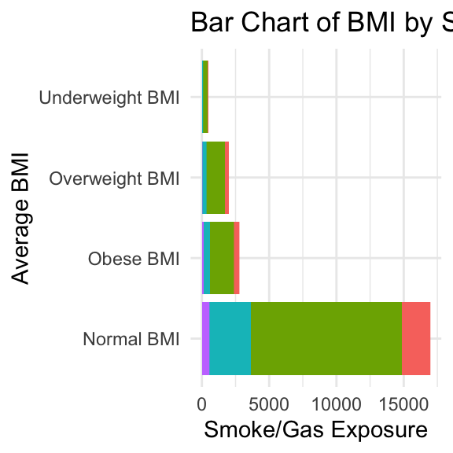

```r
#Visualization Q3 - Barchart of BMI by smoke/gas exposure.
ggplot(chs, aes(x = bmi, y = obesity_level, fill=smoke_gas_exposure)) +
  geom_bar(stat = "identity") +
  labs(title = "Bar Chart of BMI by Smoke/Gas Exposure",
       x = "Smoke/Gas Exposure",
       y = "Average BMI") +
  theme_minimal() +
  theme(legend.position = "none")
```

The greatest number of smoke/gas exposures occurred in individuals with Normal BMI, followed by individuals with Obese BMI, Overweight BMI, and Underweight BMI. However, we cannot conclude an association between one’s BMI and smoke/gas exposure because they are both nominal variables.

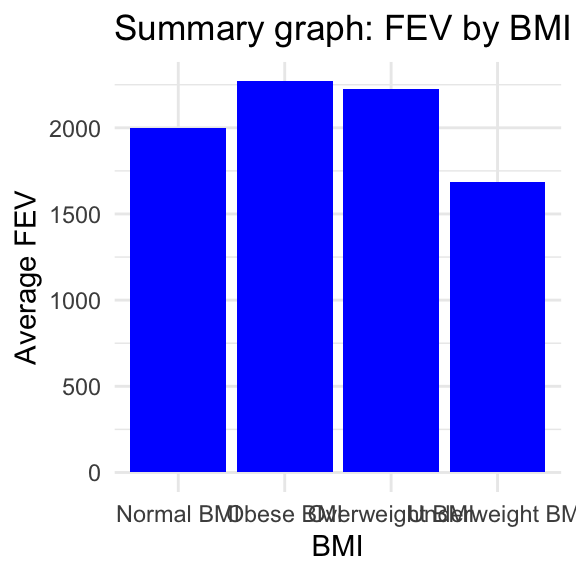

```r
#Visualization Q4-- Statistical summary graphs of FEV by BMI and FEV by smoke/gas exposure category.
ggplot(summary_obesity_level, aes(x = obesity_level, y = avg_fevobesity_level)) +
  geom_bar(stat = "identity", fill = "blue") +
  labs(title = "Summary graph: FEV by BMI",
       x = "BMI",
       y = "Average FEV") +
  theme_minimal()
```

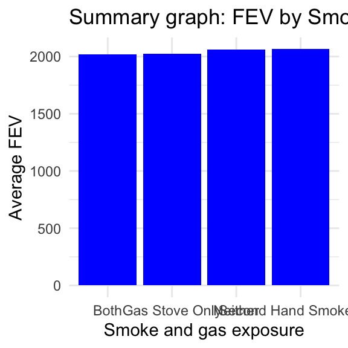

```r
ggplot(summary_smoke_gas, aes(x = smoke_gas_exposure, y = avg_fevsmoke_gas, fill = smoke_gas_exposure)) +
  geom_bar(stat = "identity", fill = "blue") +
  labs(title = "Summary graph: FEV by Smoke/gas exposure categories",
       x = "Smoke and gas exposure",
       y = "Average FEV") +
  theme_minimal()
```

Overall, each category of individuals had the same average FEV, regardless of smoke and gas exposure categories.

Additionally, the BMI categories “Overweight” and “Obese” had higher average FEVs in comparison to normal BMI and underweight BMI. This supports the association such that higher BMI leads to higher FEV levels.

```r
#Visualization Q5. A leaflet map showing the concentrations of PM2.5 mass in each of the CHS communities.
library(leaflet)

leaflet(chs) %>%
  addTiles() %>%
  addCircleMarkers(
    ~lon, ~lat,
    radius = ~pm25_mass,
    color = "blue",
    stroke = FALSE,
    fillOpacity = 0.5,
    popup = ~paste(townname, "<br>", "PM2.5 Concentration:", pm25_mass, "µg/m³")
  ) %>%
  setView(lng = mean(chs$lon), lat = mean(chs$lat), zoom = 5)
```

[interactive chart not shown]

The leaflet map shows high concentrations of PM2.5 mass in the southern california region, more specifically inland in Mira Loma (pm 2.5 concentration =29.97 ug/m^3) and Upland (pm 2.5 concentration =22.46 ug/m^3

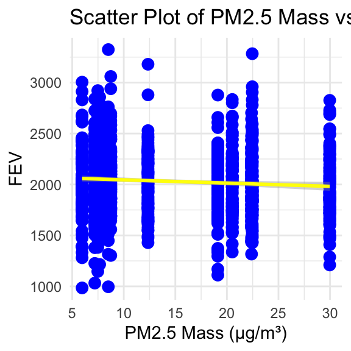

```r
#Visualization Q6 -- . Choose a visualization to examine whether PM2.5 mass is associated with FEV.

#regression line
ggplot(chs, aes(x = pm25_mass, y = fev)) +
  geom_point(color = "blue", size = 3) +  # Scatter points
  geom_smooth(method = "lm", se = TRUE, color = "yellow") +  # Linear regression line
  labs(title = "Scatter Plot of PM2.5 Mass vs. FEV",
       x = "PM2.5 Mass (µg/m³)",
       y = "FEV") +
  theme_minimal()
```

```r
# Perform correlation test
cor_test <- cor.test(chs$pm25_mass, chs$fev)

cor_test
```

```
    Pearson's product-moment correlation

data:  chs$pm25_mass and chs$fev
t = -2.4884, df = 1103, p-value = 0.01298
alternative hypothesis: true correlation is not equal to 0
95 percent confidence interval:
 -0.13310296 -0.01581316
sample estimates:
        cor
-0.07471647
```